# PREDICTION DE LA PRODUCTION DU CACAO IVOIRIEN EN 2025

## Introduction

- **date** : Indique l’année de la donnée de production, allant de 1960 à 2024.
- **Production (en tonnes)** : La quantité totale de fèves de cacao produites chaque année.
- **Prix à la production (FCFA/Kg)** : Le prix moyen du cacao sur le marché international pour chaque année.

|  | date | Prix | Production |
| --- | --- | --- | --- |
| 1 | 1960 | 95 | 94619 |
| 2 | 1961 | 95 | 80998 |
| 3 | 1962 | 70 | 103038 |
| 4 | 1963 | 70 | 98319 |
| 5 | 1964 | 76.8 | 147529 |
| 6 | 1965 | 76.96 | 113287 |
| 7 | 1966 | 61.96 | 149662 |
| 8 | 1967 | 77.12 | 146817 |
| 9 | 1968 | 77.95 | 141778 |
| 10 | 1969 | 74.2 | 183012 |

[output cut: 55 more lines]

## La visualisation de l’ensemble des données

[interactive chart not shown]

La visualisation graphique sur l’ensemble des données montre une valeur manquante de la production du cacao en 1999. Nous pensons que cette valeur manquante est dû au coup d’Etat de 1999. il faut noter qu’il existe plusieurs méthodes pour gérer les valeurs manquantes dans un jeu de donnée donc tout dépend du contexte dans lequel on se trouve. ces differentes méthodes sont:

- Faire un revue litterraire
- imputer par la moyenne ou la mediane
- les supprimées Dans notre cas, nous allons les remplacer par la moyenne.

## Analyse descriptive

L’analyse descriptive est une étape essentielle dans l’analyse de données, car elle permet de resumer et de comprendre les caractéristiqques principales d’un jeu de données.

- Resumé statistique (la moyenne, la madiane…)

```
##    Min. 1st Qu.  Median    Mean 3rd Qu.    Max.
##   80998  245000  848863  920505 1367200 2248000
```

- **Min (Minimum) : 80998** Est la plus petite valeur observée dans le jeu de données. Cela signifie que la production annuelle la plus faible enregistrée est de 80 998 tonnes.
- **1st Qu. (1er Quartile) : 245000** 25% des valeurs de la production de cacao sont inférieures à 245 000 tonnes. Le 1er quartile représente le point en dessous duquel se situe le quart inférieur des données.
- **Median (Médiane) : 848863** La valeur médiane de la production est de 848 863 tonnes. Cela signifie que 50% des valeurs sont inférieures et 50% sont supérieures à cette valeur. La médiane est une mesure de la tendance centrale qui n’est pas influencée par les valeurs aberrantes.
- **Mean (Moyenne) : 920505** La moyenne de la production annuelle est de 920 505 tonnes. Cette valeur est calculée en additionnant toutes les productions annuelles et en divisant par le nombre d’années. La moyenne peut être influencée par les valeurs aberrantes.
- **3rd Qu. (3ème Quartile) : 1367200** 75% des valeurs de la production de cacao sont inférieures à 1 367 200 tonnes. Le 3ème quartile représente le point en dessous duquel se situent les trois quarts des données.
- **Max (Maximum) : 2248000** La plus grande valeur observée dans le jeu de données. Cela signifie que la production annuelle la plus élevée enregistrée est de 2 248 000 tonnes.
- **Valeur aberrante** Les valeurs aberrantes (ou outliers) sont des observations qui se distinguent nettement des autres données. Elles peuvent résulter d’erreurs de mesure ou indiquer des cas exceptionnels qui méritent une attention particulière
- **boxplot pour la variables production**

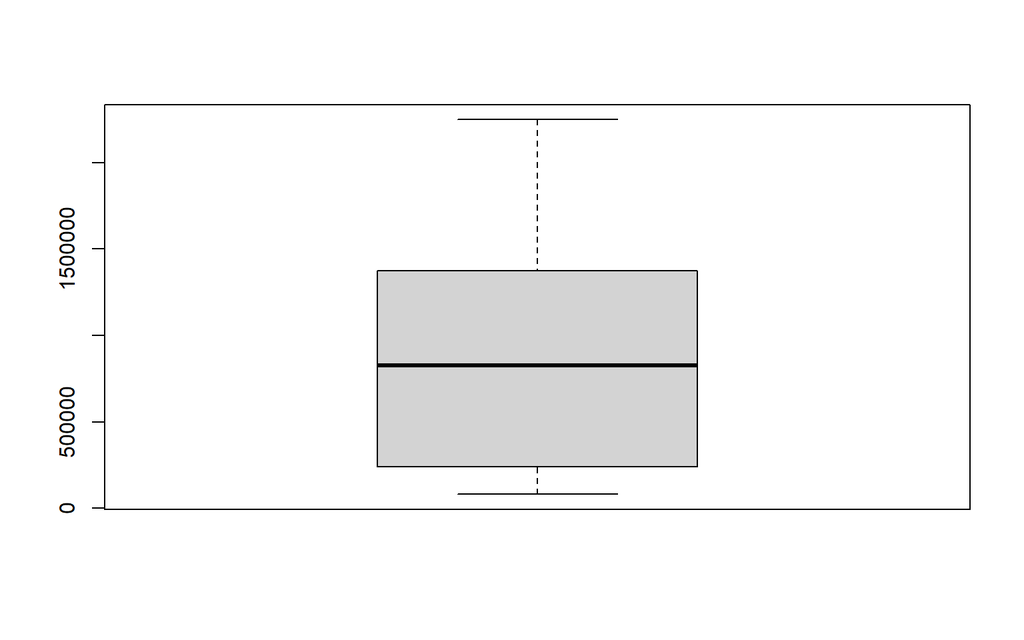

vu le boxplot il n’existe pas de valeur aberrante pour la variable **production** notre jeu de donnée est un dataframe nous devrons le convertir en ts.

```
## Time Series:
## Start = c(1960, 1)
## End = c(1962, 2)
## Frequency = 2
##         Prix Production
## 1960.0 95.00      94619
## 1960.5 95.00      80998
## 1961.0 70.00     103038
## 1961.5 70.00      98319
## 1962.0 76.80     147529
## 1962.5 76.96     113287
```

```
##  The cacao series is a mts object with 2 variables and 65 observations
##  Frequency: 2
##  Start time: 1960 1
##  End time: 1992 1
```

## Modelisation de notre problème.

La modélisation d’une série temporelle permet de comprendre les structures sous-jacentes des données et de faire des prévisions avec des modèle tel que **ARMA, ARIMA, SARIMA**. c’est different modèle remplit certain hypothèse.

### La Stationnarisation

Une série temporelle est dite stationnaire si ses propriétés statistiques (comme la moyenne, la variance et l’autocorrélation) sont constantes au cours du temps. La stationnarité est une propriété importante dans l’analyse des séries temporelles, car de nombreux modèles, y compris les modèles ARIMA, supposent que la série est stationnaire.

**Pourquoi la stationnarité est-elle importante ?**

- Modélisation simplifiée : Les modèles pour séries temporelles stationnaires sont plus simples et ont des propriétés théoriques bien définies.
- Prédictibilité : Les prévisions pour les séries stationnaires sont généralement plus fiables.
- Éviter les faux résultats : Analyser une série non-stationnaire peut conduire à des conclusions incorrectes.

**Pour vérifier si une série est stationnaire, plusieurs tests peuvent être utilisés** :

- test **ADF**

Test de Dickey-Fuller augmenté (ADF) : Teste l’hypothèse nulle que la série a une racine unitaire (non stationnaire).

**Interprétation des Résultats**

- **Hypothèse nulle (H0)** : La série temporelle a une racine unitaire (elle est non stationnaire).
- **Hypothèse alternative (H1)** : La série temporelle n’a pas de racine unitaire (elle est stationnaire).
  - Pour prendre une décision :

Si la **p-value** est inférieure à un seuil (généralement 0.05), on rejette l’hypothèse nulle, indiquant que la série est stationnaire. Si la **p-value** est supérieure à ce seuil, on ne rejette pas l’hypothèse nulle, indiquant que la série est non stationnaire.

```
##
##  Augmented Dickey-Fuller Test
##
## data:  production_ts
## Dickey-Fuller = -2.0067, Lag order = 5, p-value = 0.5737
## alternative hypothesis: stationary
```

- test **KPSS**

Test KPSS (Kwiatkowski-Phillips-Schmidt-Shin) : Teste l’hypothèse nulle que la série est stationnaire autour d’une moyenne ou d’une tendance déterministe.

**Interprétation des Résultats**

- **Hypothèse nulle (H0)** : La série temporelle est stationnaire autour d’une moyenne ou d’une tendance déterministe.
- **Hypothèse alternative (H1)** : La série temporelle est non stationnaire.
  - Pour prendre une décision :

Si la p-value est inférieure à un seuil (généralement 0.05), on rejette l’hypothèse nulle, indiquant que la série est non stationnaire. Si la p-value est supérieure à ce seuil, on ne rejette pas l’hypothèse nulle, indiquant que la série est stationnaire.

```
##
##  KPSS Test for Level Stationarity
##
## data:  production_ts
## KPSS Level = 0.67237, Truncation lag parameter = 4, p-value = 0.01606
```

- test **pp**

Le test de racine unitaire de Phillips-Perron (PP) est utilisé pour tester l’hypothèse nulle selon laquelle une série temporelle a une racine unitaire, ce qui signifie qu’elle est non stationnaire. Voici l’interprétation des résultats de votre test PP :

**Interprétation des Résultats**

- **Hypothèse nulle (H0)** : La série temporelle a une racine unitaire (elle est non stationnaire).
- **Hypothèse alternative (H1)** : La série temporelle n’a pas de racine unitaire (elle est stationnaire).
  - Pour prendre une décision :
- Si la **p-value** est inférieure à un seuil (généralement 0.05), on rejette l’hypothèse nulle, indiquant que la série est stationnaire.
- Si la **p-value** est supérieure à ce seuil, on ne rejette pas l’hypothèse nulle, indiquant que la série est non stationnaire.

```
##
##  Phillips-Perron Unit Root Test
##
## data:  production_ts
## Dickey-Fuller Z(alpha) = -8.1967, Truncation lag parameter = 4, p-value
## = 0.6427
## alternative hypothesis: stationary
```

**Resumé dans un tableau des differentes test avec les probalbilité (p_valeur)**

| test | ADF | kpss | pp |
| --- | --- | --- | --- |
| p_valeur | 0.5737 | 0.01606 | 0.6427 |
| stationnarité | Non | Non | Non |

On remarque que pour ces trois test la serie n’est pas stationnaire. donc nous devons la rendre stationnaire en la differenciant. l’ordre de la série differencie est:

```
## [1] 1
```

**la visualisation après différenciation**

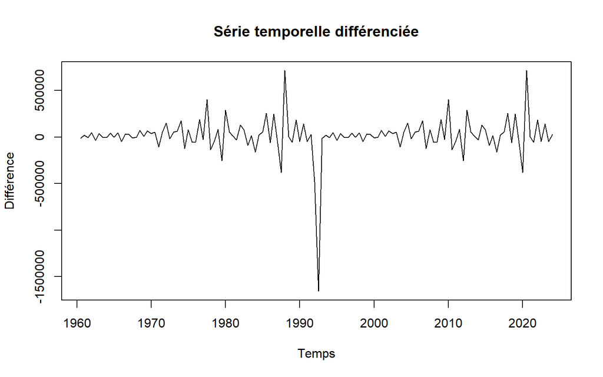

```
##
##  Augmented Dickey-Fuller Test
##
## data:  diff_ts_data
## Dickey-Fuller = -4.7303, Lag order = 5, p-value = 0.01
## alternative hypothesis: stationary
```

[output not shown]

```
##
##  Phillips-Perron Unit Root Test
##
## data:  diff_ts_data
## Dickey-Fuller Z(alpha) = -131.73, Truncation lag parameter = 4, p-value
## = 0.01
## alternative hypothesis: stationary
```

**Resumé dans un tableau des differentes test avec les probalbilité (p_valeur) après différenciation de la série**

[output not shown]

- Identification du modèle: trouver $p$, $q$ et $d$
  - **Analyse de l’ordre p et q**

En modélisant une série temporelle avec un modèle ARIMA (AutoRegressive Integrated Moving Average), les paramètres $p$ et $q$ sont déterminés en examinant les graphiques de la fonction d’autocorrélation (PACF) et de la fonction d’autocorrélation partielle (ACF) :

1. **Détermination de $p$ (Ordre du composant autorégressif AR) :**
   - Pour déterminer $p$, observez le graphique de la fonction d’autocorrélation partielle (PACF).
   - Le paramètre $p$ correspond au dernier décalage significatif dans le graphique PACF. Autrement dit, après le décalage $p$, les autocorrélations partielles devraient être non significatives (proches de zéro).
   - cela signifie que nous cherchons le nombre de barres (lags) dans le graphique PACF qui sont significativement différentes de zéro.

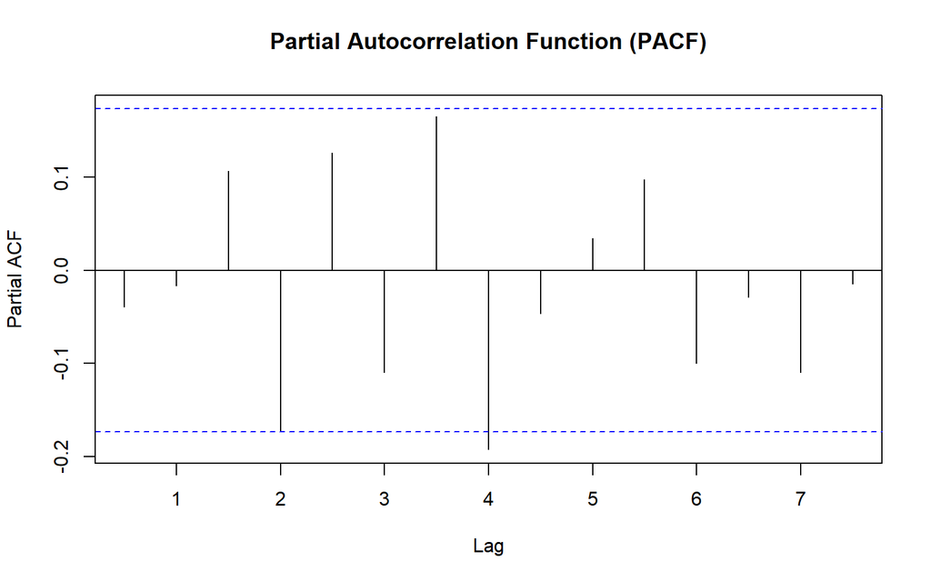

2. **Détermination de $q$ (Ordre du composant de moyenne mobile MA) :**
   - Pour déterminer $q$, examinez le graphique de la fonction d’autocorrélation (ACF).
   - Le paramètre $q$ correspond au dernier décalage significatif dans le graphique ACF. Cela signifie que nous cherchons le nombre de barres (lags) dans le graphique ACF qui sont significativement différentes de zéro.

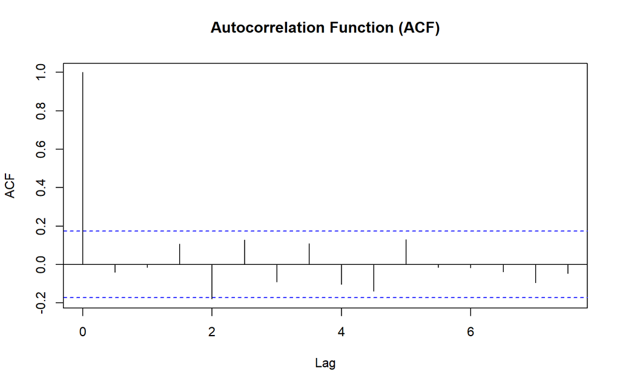

```
##
##  Box-Ljung test
##
## data:  diff_ts_data
## X-squared = 6.0724, df = 4, p-value = 0.1938
```

**En conclusion $p=0$, $q=0$ et $d=1$**

## Estimation

- **Estimation automatique**

j’ai calibré p à 4 parce-que nous avons des doutes en 4

```
## Series: production_ts
## ARIMA(0,1,0)
##
## sigma^2 = 4.547e+10:  log likelihood = -1752.2
## AIC=3506.4   AICc=3506.43   BIC=3509.25
##
## Training set error measures:
##                    ME     RMSE    MAE       MPE    MAPE      MASE        ACF1
## Training set 16554.07 212403.2 107261 -10.17222 25.5324 0.7207649 -0.03934562
```

Nous retenons comme meilleur modèle **ARIMA(0,1,0)**

## Validation du modèle

Après avoir ajusté un modèle ARIMA, il est crucial de vérifier les résidus du modèle pour s’assurer de la qualité de l’ajustement. Les résidus sont la différence entre les valeurs observées et les valeurs prédites par le modèle. Si le modèle est bien ajusté, les résidus doivent se comporter comme un bruit blanc, c’est-à-dire être une série temporelle aléatoire à distribution normale, avec une moyenne de zéro et sans autocorrélation. Voici quelques points clés à vérifier :

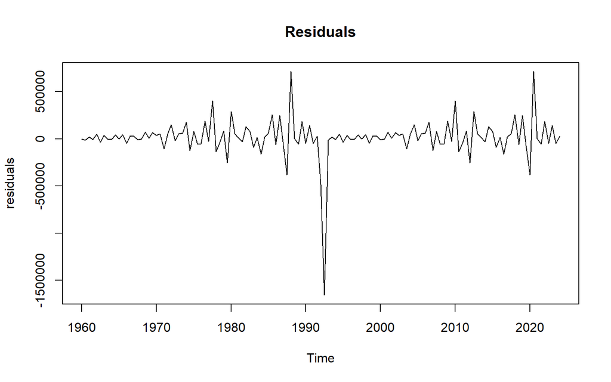

- **Test de Ljung-Box**

Le test de Ljung-Box teste l’absence d’autocorrélation dans les résidus. Nous voulons que les résidus soient indépendants les uns des autres. Une faible valeur p (p < 0,05) indique une preuve d’autocorrélation.

```
##             Order Test_Statistic    P_Value
## X-squared       1      0.2043825 0.65120641
## X-squared1      2      0.2345036 0.88936123
## X-squared2      3      1.7871226 0.61774121
## X-squared3      4      6.1225197 0.19018336
## X-squared4      5      8.3521933 0.13786405
## X-squared5      6      9.4569701 0.14946220
## X-squared6      7     11.1297378 0.13305919
## X-squared7      8     12.5915409 0.12669761
## X-squared8      9     15.2876203 0.08333250
## X-squared9     10     17.7092030 0.06007162
## X-squared10    11     17.7381002 0.08785995
## X-squared11    12     17.7783151 0.12258930
```

- **Hétéroscédasticité**

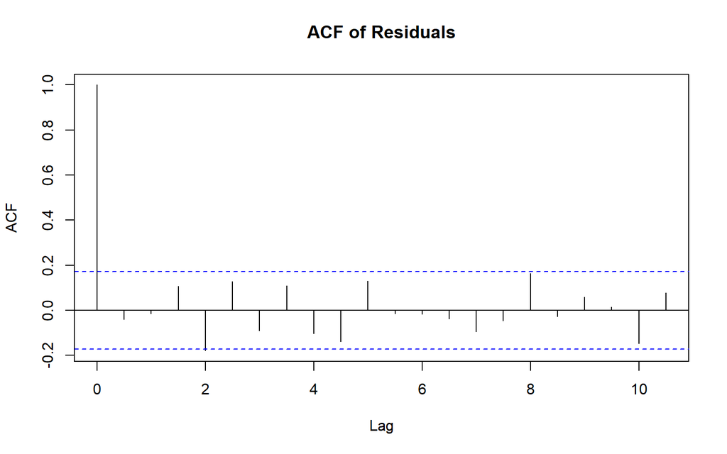

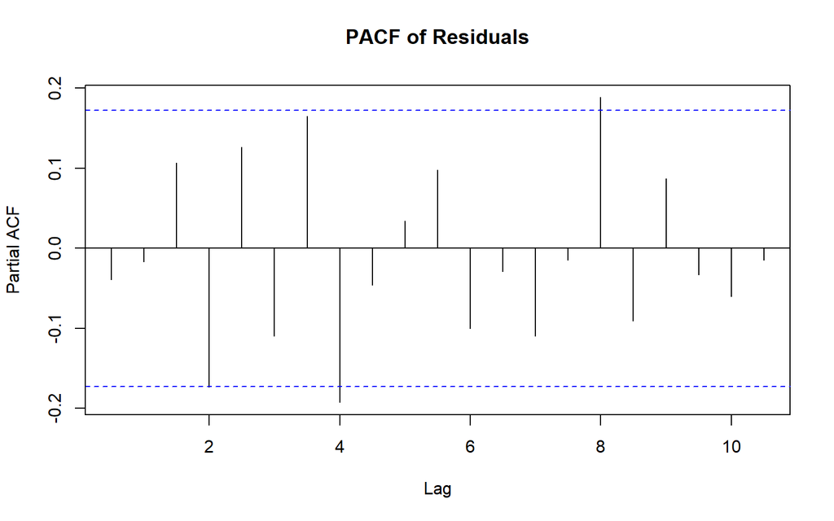

- **Normalité**

L’aspect de normalité fait référence à la distribution des résidus. Dans un bon modèle, nous attendons que les résidus suivent une distribution normale. Pour vérifier cela, nous pouvons utiliser un graphique Q-Q ou effectuer un test statistique, comme le test de **Shapiro-Wilk**, pour vérifier la normalité.

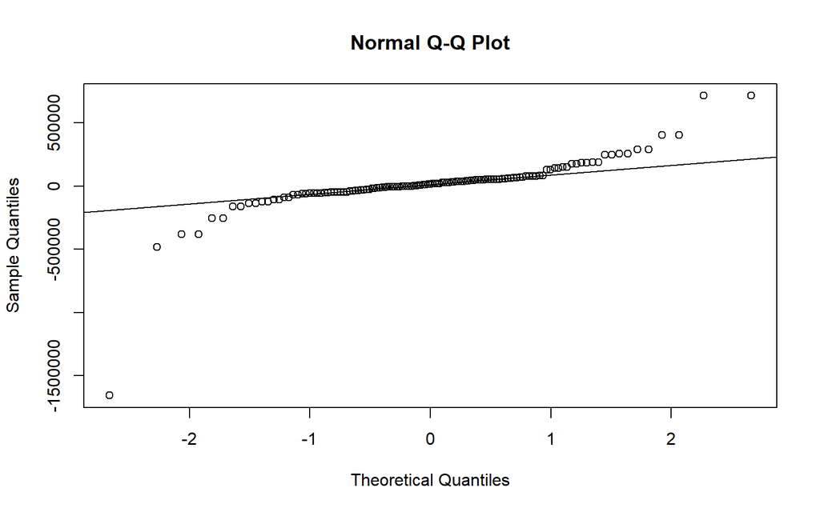

Le graphe qq nous montre que les résidus ne suivent pas une distribution normale. pour confirmer cela nous allons mettre le test de **Shapiro-Wilk**

```
##
##  Shapiro-Wilk normality test
##
## data:  residuals
## W = 0.65733, p-value = 6.221e-16
```

- **Graphiques des résidus**

En plus des tests statistiques, il est utile de tracer les résidus au fil du temps, ainsi que leur autocorrélation (ACF et PACF), pour vérifier visuellement les suppositions précédentes. Dans un modèle bien ajusté, les résidus devraient ressembler à un bruit blanc lorsqu’ils sont tracés dans le temps, et l’ACF et le PACF devraient montrer peu ou pas de corrélation significative.

## Prédiction

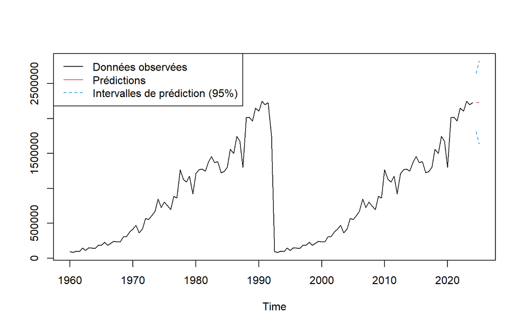